# scRNA-seq: pc27mitonows26_gtf

Andrea Elizabeth Acurio Armas, Bulah Wu, Petr Nguyen

July 29, 2024

# Digital expression matrix

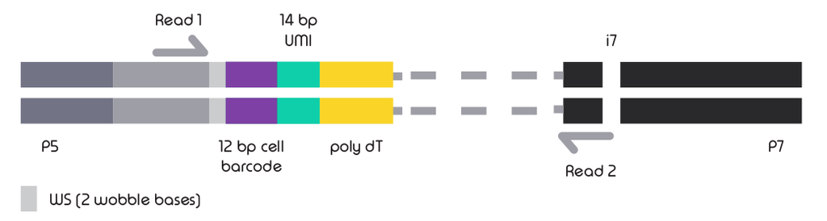

RNAdia barcode geometry

According to the manual of RNAdia 2.0 kit (Dolomite Bio), the barcode sequence is located on Read 1, including a fragment of 2-nt “wobble bases”, 12-nt cell barcode (CB) and 14-nt unique molecular identifier (UMI). Before constructing the count matrix, Read 1 raw reads were trimmed to keep only the 26-nt barcode fragment. The matrix was then built according to the Drop-seq core computational protocol developed by the McCarroll Lab (https://github.com/broadinstitute/Drop-seq).

```
#!/bin/bash
#PBS -N pc27mitonows26_gtf
#PBS -l select=1:ncpus=16:mem=140gb:scratch_ssd=800gb
#PBS -l walltime=24:00:00
#PBS -m ae

#export TMPDIR=$SCRATCHDIR
DATADIR=/storage/plzen1/home/bulah/mao/scseq/dropseq/pc27mitonows26_gtf
echo "||| $HOSTNAME $SCRATCHDIR ||| (pc27mitonows26_gtf) ||| ssh $HOSTNAME \"scp -rp bulah@$HOSTNAME:$SCRATCHDIR/* \$HOSTNAME:\$SCRATCHDIR\" |||" >> $DATADIR/jobid

module add mambaforge picard star samtools
mamba activate /storage/plzen1/home/bulah/.conda/envs/openjdk2201

export ID=pc27mitonows26_gtf
export ASSEMBLY=/storage/plzen1/home/bulah/mao/braker3/phymatopus_californicus/genome_mao/repeatmodeler/phycal_genome_masked2.fa
export ANNOTATION=/storage/plzen1/home/bulah/mao/braker3/phymatopus_californicus/genome_mao/braker3/edit02_phycal_mito.gtf
export READ1=/storage/plzen1/home/bulah/mao/scseq/X201SC24042690-Z01-F001/remove_2nt_wobble_bases/nows26_pc27_1.fq.gz
export READ2=/storage/plzen1/home/bulah/mao/scseq/X201SC24042690-Z01-F001/X201SC24042690-Z01-F001/01.RawData/PC_27/PC_27_2.fq.gz

mkdir -p $SCRATCHDIR/dropseq/genome $SCRATCHDIR/dropseq/project_${ID}/{tmp,raw,output_${ID}}
export DROPSEQDIR=$SCRATCHDIR/dropseq
 export GENOMEDIR=$DROPSEQDIR/genome
 export WORKDIR=$DROPSEQDIR/project_${ID}
  export TMPDIR=$WORKDIR/tmp
  export RAWDIR=$WORKDIR/raw
  export OUTPUTDIR=$WORKDIR/output_${ID}
export PATH=$PATH:$DROPSEQDIR/dropseq-3.0.1

cd $DROPSEQDIR

if [ ! -d "$DROPSEQDIR"/dropseq-3.0.1 ]; then
  wget https://github.com/broadinstitute/Drop-seq/releases/download/v3.0.1/dropseq-3.0.1.zip
  unzip dropseq-3.0.1.zip
  rm -rf dropseq-3.0.1.zip
fi

if [ ! -f "$GENOMEDIR"/genome.fa ]; then
  cp -rp $ASSEMBLY $GENOMEDIR/genome.fa
  cp -rp $ANNOTATION $GENOMEDIR/genome.gtf
  STAR --runMode genomeGenerate --genomeDir $GENOMEDIR --genomeFastaFiles $GENOMEDIR/genome.fa --sjdbGTFfile $GENOMEDIR/genome.gtf --genomeSAindexNbases 13 --runThreadN $PBS_NCPUS
fi

if [ ! -f "$GENOMEDIR"/genome.dict ]; then
  picard CreateSequenceDictionary -R $GENOMEDIR/genome.fa --TMP_DIR $TMPDIR
fi

cp -rp $READ1 $RAWDIR/read1.fq.gz
cp -rp $READ2 $RAWDIR/read2.fq.gz

picard FastqToSam -F1 $RAWDIR/read1.fq.gz -F2 $RAWDIR/read2.fq.gz -O $OUTPUTDIR/unaligned.bam -SM ${ID} --TMP_DIR $TMPDIR

TagBamWithReadSequenceExtended -SUMMARY $OUTPUTDIR/unaligned_tagged_Cellular.bam_summary.txt -BASE_RANGE 1-12 -BASE_QUALITY 10 -BARCODED_READ 1 -DISCARD_READ false -TAG_NAME XC \
-NUM_BASES_BELOW_QUALITY 1 -INPUT $OUTPUTDIR/unaligned.bam -OUTPUT $OUTPUTDIR/unaligned_tagged_Cell.bam -TMP_DIR $TMPDIR

TagBamWithReadSequenceExtended -SUMMARY $OUTPUTDIR/unaligned_tagged_Molecular.bam_summary.txt -BASE_RANGE 13-26 -BASE_QUALITY 10 -BARCODED_READ 1 -DISCARD_READ true -TAG_NAME XM \
-NUM_BASES_BELOW_QUALITY 1 -INPUT $OUTPUTDIR/unaligned_tagged_Cell.bam -OUTPUT $OUTPUTDIR/unaligned_tagged_CellMolecular.bam -TMP_DIR $TMPDIR

FilterBam -TAG_REJECT XQ -INPUT $OUTPUTDIR/unaligned_tagged_CellMolecular.bam -OUTPUT $OUTPUTDIR/unaligned_tagged_filtered.bam -SUMMARY $OUTPUTDIR/unaligned_tagged_filtered.bam_summary.txt -TMP_DIR $TMPDIR

TrimStartingSequence -OUTPUT_SUMMARY $OUTPUTDIR/adapter_trimming_report.txt -SEQUENCE AAGCAGTGGTATCAACGCAGAGTGAATGGG -MISMATCHES 0 -NUM_BASES 5 -INPUT $OUTPUTDIR/unaligned_tagged_filtered.bam -OUTPUT $OUTPUTDIR/unaligned_tagged_trimmed_smart.bam -TMP_DIR $TMPDIR

PolyATrimmer -OUTPUT $OUTPUTDIR/unaligned_mc_tagged_polyA_filtered.bam -OUTPUT_SUMMARY $OUTPUTDIR/polyA_trimming_report.txt -MISMATCHES 0 -NUM_BASES 6 -NEW true -INPUT $OUTPUTDIR/unaligned_tagged_trimmed_smart.bam -TMP_DIR $TMPDIR

picard SamToFastq --INPUT $OUTPUTDIR/unaligned_mc_tagged_polyA_filtered.bam --FASTQ $OUTPUTDIR/unaligned_mc_tagged_polyA_filtered.fastq --TMP_DIR $TMPDIR

STAR --genomeDir $GENOMEDIR --outFileNamePrefix $OUTPUTDIR/star --readFilesIn $OUTPUTDIR/unaligned_mc_tagged_polyA_filtered.fastq --runThreadN $PBS_NCPUS

picard SortSam --INPUT $OUTPUTDIR/starAligned.out.sam --OUTPUT $OUTPUTDIR/aligned.sorted.bam --SORT_ORDER queryname --TMP_DIR $TMPDIR

picard MergeBamAlignment --REFERENCE_SEQUENCE $GENOMEDIR/genome.fa --UNMAPPED_BAM $OUTPUTDIR/unaligned_mc_tagged_polyA_filtered.bam --ALIGNED_BAM $OUTPUTDIR/aligned.sorted.bam \
--INCLUDE_SECONDARY_ALIGNMENTS false --PAIRED_RUN false --CLIP_ADAPTERS false --OUTPUT $OUTPUTDIR/merged.bam --TMP_DIR $TMPDIR

TagReadWithGeneFunction -INPUT $OUTPUTDIR/merged.bam -OUTPUT $OUTPUTDIR/function_tagged.bam -ANNOTATIONS_FILE $GENOMEDIR/genome.gtf -TMP_DIR $TMPDIR

DetectBeadSubstitutionErrors -INPUT $OUTPUTDIR/function_tagged.bam -OUTPUT $OUTPUTDIR/substitution_repaired.bam -MIN_UMIS_PER_CELL 20 -OUTPUT_REPORT $OUTPUTDIR/substitution_error_report.txt -NUM_THREADS $PBS_NCPUS -TMP_DIR $TMPDIR

DetectBeadSynthesisErrors -INPUT $OUTPUTDIR/substitution_repaired.bam -MIN_UMIS_PER_CELL 20 -OUTPUT_STATS $OUTPUTDIR/synthesis_error_stats.txt -SUMMARY $OUTPUTDIR/synthesis_error_summary.txt \
-PRIMER_SEQUENCE AAGCAGTGGTATCAACGCAGAGTAC -REPORT $OUTPUTDIR/synthesis_error_report.txt -CREATE_INDEX true -OUTPUT $OUTPUTDIR/final.bam -NUM_THREADS $PBS_NCPUS -TMP_DIR $TMPDIR

DigitalExpression -INPUT $OUTPUTDIR/final.bam -OUTPUT $OUTPUTDIR/dge_c8k.txt.gz -SUMMARY $OUTPUTDIR/dge_c8k.summary.txt -NUM_CORE_BARCODES 8000 -TMP_DIR $TMPDIR

BamTagHistogram -INPUT $OUTPUTDIR/final.bam -OUTPUT $OUTPUTDIR/cell_readcounts.txt.gz -TAG XC -TMP_DIR $TMPDIR
```

# Knee-plot analysis

In the dot plot, the x-axis represents the cell barcodes (organized by the number of reads, arranged from highest to lowest), and the y-axis shows the cumulative fraction of uniquely mapped reads. The transition from beads sampling cellular RNA to beads sampling ambient RNA is marked by the inflection point ([Macosko et al., 2015](http://dx.doi.org/10.1016/j.cell.2015.05.002)).

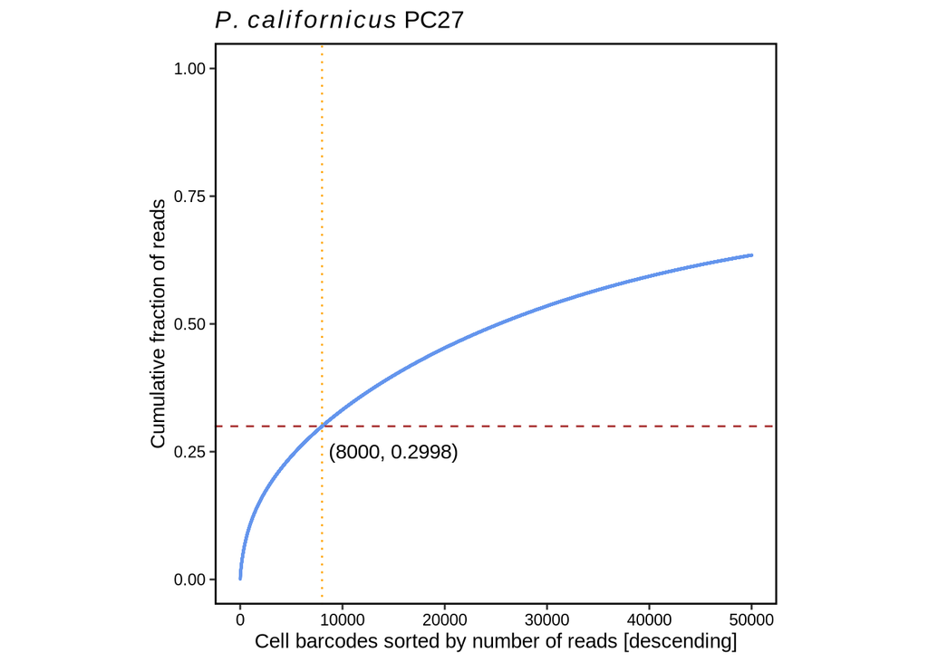

```r
pc27=read.table("/media/nguyen/Data1/mao/scseq/dropseq/pc27mitonows26_gtf/cell_readcounts.txt.gz", header=F, stringsAsFactors=F)
csum_pc27=cumsum(pc27$V1)
df_pc27 <- cbind.data.frame(xvalue=1:length(csum_pc27), yvalue=csum_pc27/max(csum_pc27))
ggplot(df_pc27, aes(xvalue, yvalue)) +
  geom_point(size=0.1, color="cornflowerblue") + scale_x_continuous(limits = c(0,50000))+
  geom_hline(aes(yintercept=df_pc27 %>% filter(xvalue==8000) %>% pull(yvalue)), color="brown", linetype=2)+
  geom_vline(aes(xintercept=8000), color="orange", linetype=3)+
  annotate("text", x=15000, y=0.25, label="(8000, 0.2998)")+ # 0.2997816
  labs(title=expression(italic(P.)~italic(californicus)~"PC27"), x="Cell barcodes sorted by number of reads [descending]", y="Cumulative fraction of reads") +
  theme_bw() +
  theme(axis.line = element_blank(),
        axis.title = element_text(color="black"),
        axis.text = element_text(color="black"),
        panel.grid.major = element_blank(),
        panel.grid.minor = element_blank(),
        panel.background = element_blank(),
        panel.border = element_rect(linewidth = 1, color="black"), aspect.ratio = 1)
```

The plot indicates the top 8000 cells contribute nearly 30% of the total uniquely mapped reads.

# DropletUtils analysis

Here the x-axis indicates the cell barcodes (organized by the number of reads, arranged from highest to lowest) and the y-axis the total UMI count for each barcode.

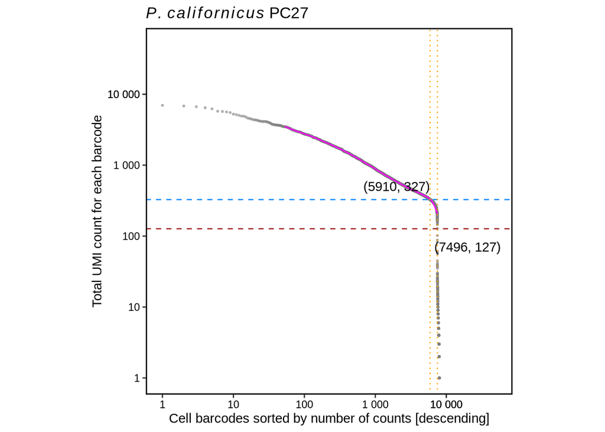

```r
mtx_pc27 <- read.table("/media/nguyen/Data1/mao/scseq/dropseq/pc27mitonows26_gtf/dge_c8k.txt.gz", header = TRUE, row.names = 1, colClasses =c("character", rep("numeric", 8000)))
br.out <- barcodeRanks(mtx_pc27)
o <- order(br.out$rank)
# metadata(br.out)$knee: 327
# metadata(br.out)$inflection : 127
# which(br.out$total==327)[1]
min_rank <- br.out$rank[which(br.out$total==327)[1]] # 5910
# which(br.out$total==127)[1]
max_rank <- br.out$rank[which(br.out$total==127)[1]] # 7496
ggplot()+
  geom_point(aes(x=br.out$rank, y=br.out$total+1), color="grey50", size=0.5, alpha=0.5)+
  geom_line(aes(x=br.out$rank[o],y=br.out$fitted[o]), color="magenta")+
  geom_hline(aes(yintercept=metadata(br.out)$knee), color="dodgerblue", linetype=2)+
  geom_hline(aes(yintercept=metadata(br.out)$inflection), color="brown", linetype=2)+
  geom_vline(aes(xintercept=min_rank), color="orange", linetype=3)+
  geom_vline(aes(xintercept=max_rank), color="orange", linetype=3)+
  annotate("text", x=2000, y=500, label="(5910, 327)")+
  annotate("text", x=20000, y=70, label="(7496, 127)")+
  scale_x_continuous(limits=c(1,50000), trans='log10', breaks = c(1,10,100,1000,10000,10000),labels = scales::number)+
  scale_y_continuous(limits=c(1,50000), trans='log10', breaks = c(1,10,100,1000,10000,10000),labels = scales::number)+
  labs(title=expression(italic(P.)~italic(californicus)~"PC27"),
       x="Cell barcodes sorted by number of counts [descending]",
       y="Total UMI count for each barcode") +
  theme_bw() +
  theme(axis.line = element_blank(),
        axis.title = element_text(color="black"),
        axis.text = element_text(color="black"),
        panel.grid.major = element_blank(),
        panel.grid.minor = element_blank(),
        panel.background = element_blank(),
        panel.border = element_rect(linewidth = 1, color="black"), aspect.ratio = 1)
```

Cells below the knee point (5910) are considered empty droplets.

Subset the SingleCellExperiment object to discard the empty droplets.

```r
set.seed(100)
e.out <- emptyDrops(mtx_pc27, niters=10000)
is.cell <- e.out$FDR <= 0.001
sum(is.cell, na.rm=TRUE)
```

```
## [1] 5943
```

In total 5943 cells are retained.

```r
table(Limited=e.out$Limited, Significant=is.cell)
```

```
##        Significant
## Limited FALSE TRUE
##   FALSE  1554 5456
##   TRUE      0  487
```

The zero in the above table indicates no entry with false positives frequency above the threshold 0.001 (Significant FALSE) can be achieved by increasing the number of permutations (Limited TRUE). So the parameter *niters=10000* is good.

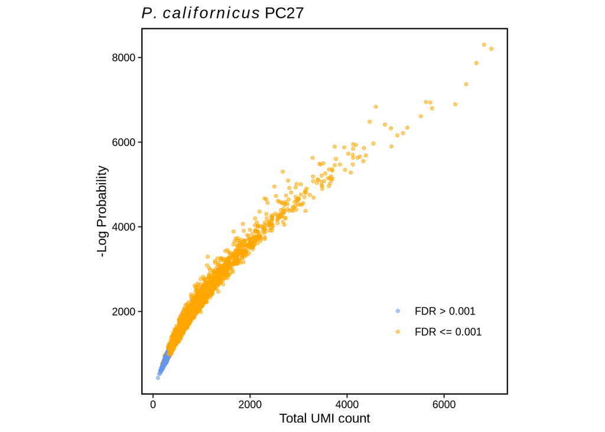

```r
mtx_pc27 <- mtx_pc27[,which(e.out$FDR<=0.001)]
ggplot(e.out %>% as.data.frame() %>% filter(!is.na(LogProb)) %>% mutate(FDR_fill=ifelse(FDR>0.001, "cornflowerblue", "orange")))+
  geom_point(aes(x=Total, y=-LogProb, color=FDR_fill), size=1, alpha=0.5)+
  scale_color_manual(values=c("cornflowerblue", "orange"), labels=c('FDR > 0.001', 'FDR <= 0.001'))+
  labs(title=expression(italic(P.)~italic(californicus)~"PC27"),
       x="Total UMI count",
       y="-Log Probability") +
  theme_bw() +
  theme(axis.line = element_blank(),
        axis.title = element_text(color="black"),
        axis.text = element_text(color="black"),
        legend.title = element_blank(),
        legend.position = "inside",
        legend.position.inside = c(0.8, 0.2),
        panel.grid.major = element_blank(),
        panel.grid.minor = element_blank(),
        panel.background = element_blank(),
        panel.border = element_rect(linewidth = 1, color="black"), aspect.ratio = 1)
```

The retained droplets (orange color) should have large UMI counts and/or large negative log probabilities.

# Analysis using Seurat

[Seurat v5](https://satijalab.org/seurat) was used to analyze the data.

First we filtered the data by dropping (1) features detected in less than 3 cells or (2) cells with feature counts less than 200.

```r
so_pc27_pre <- CreateSeuratObject(counts = mtx_pc27, min.cells = 3, min.features = 200, project = "pc27") %>%
               PercentageFeatureSet(pattern = "^agat|^rrn", col.name = "percent.mt")
```

The diagnostic plots below show the total number of unique molecules in each cell (left), the total number of unique genes in each cell (middle), and the percentage of reads mapped to the mitochondrial genome (right).

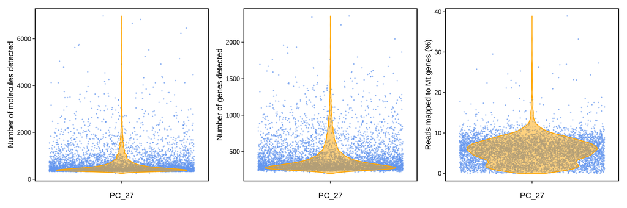

We further filtered cells (1) with feature counts larger than 2500 or less than 200 or (2) with mitochondrial counts larger than 5%.

```r
so_pc27 <- CreateSeuratObject(counts = mtx_pc27, min.cells = 3, min.features = 200, project = "pc27") %>%
           PercentageFeatureSet(pattern = "^agat|^rrn", col.name = "percent.mt") %>%
           subset(subset = nFeature_RNA > 200 & nFeature_RNA < 2500 & percent.mt < 5)
```

We checked the diagnostic plots after filtering.

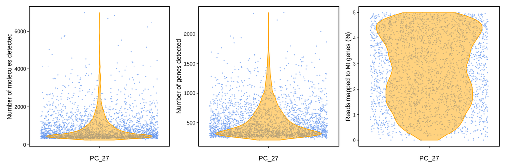

UMAP clustering of data from 2587 cells revealed 7 cell clusters.

```r
so_pc27 <- CreateSeuratObject(counts = mtx_pc27, min.cells = 3, min.features = 200, project = "pc27") %>%
           PercentageFeatureSet(pattern = "^agat|^rrn", col.name = "percent.mt") %>%
           subset(subset = nFeature_RNA > 200 & nFeature_RNA < 2500 & percent.mt < 5) %>%
           SCTransform(vars.to.regress = "percent.mt") %>%
           RunPCA() %>%
           FindNeighbors(dims = 1:30) %>%
           RunUMAP(dims = 1:30) %>%
           FindClusters()
```

```
## Modularity Optimizer version 1.3.0 by Ludo Waltman and Nees Jan van Eck
##
## Number of nodes: 2587
## Number of edges: 108934
##
## Running Louvain algorithm...
## Maximum modularity in 10 random starts: 0.7186
## Number of communities: 7
## Elapsed time: 0 seconds
```

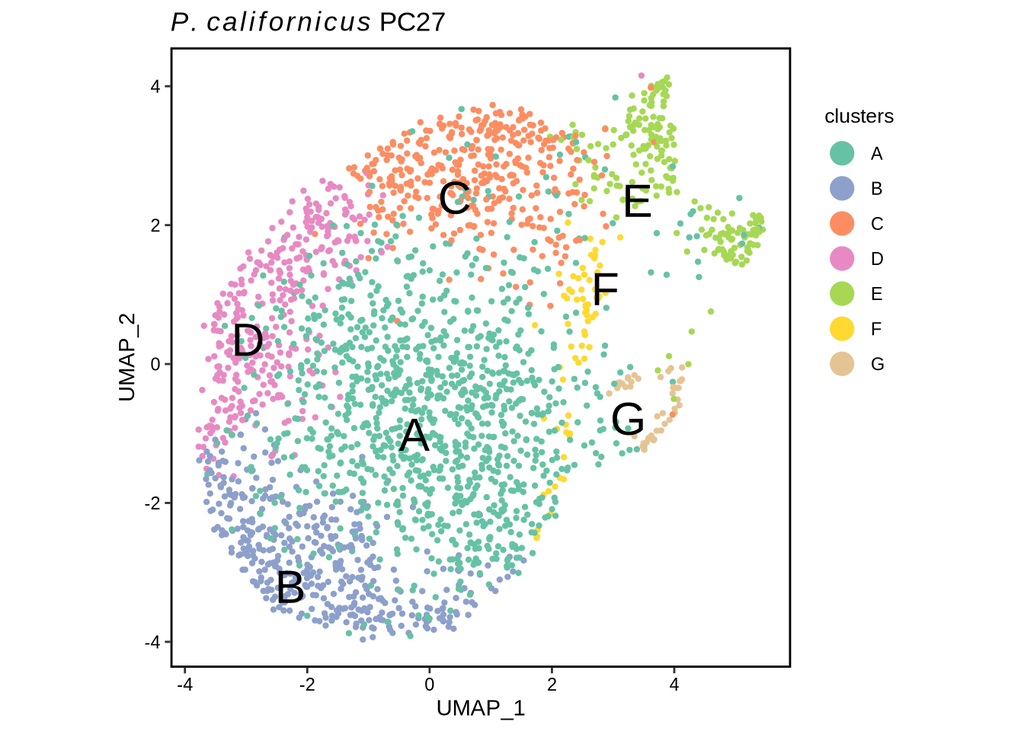

```r
df_umap <- so_pc27@reductions$umap@cell.embeddings %>% as.data.frame() %>% cbind(color=so_pc27@meta.data$seurat_clusters)
#length(unique(df_umap$color))
my_color <- c(brewer.pal(name="Set2", n=8),brewer.pal(name="Dark2", n=8))[c(1,3,2,4,5,6,7)]

ggplot(df_umap) +
  geom_point(aes(x=umap_1, y=umap_2, color=color), size=0.8) +
  geom_text_repel(data=df_umap %>% group_by(color) %>% summarise(q1=quantile(umap_1, 0.5), q2=quantile(umap_2, 0.5)),
                  aes(x=q1, y=q2, label = LETTERS[1:7]), size=8) +
  labs(title=expression(italic(P.)~italic(californicus)~"PC27"),
       x="UMAP_1",
       y="UMAP_2") +
  scale_color_manual(values = my_color, name="clusters", labels=LETTERS[1:7]) +
  guides(color = guide_legend(override.aes = list(size = 5))) +
  theme_bw() +
  theme(axis.line = element_blank(),
        axis.title = element_text(color="black"),
        axis.text = element_text(color="black"),
        legend.title = element_text(size=10),
        legend.background=element_blank(),
        legend.justification=c(1, 0.85),
        panel.grid.major = element_blank(),
        panel.grid.minor = element_blank(),
        panel.background = element_blank(),
        panel.border = element_rect(linewidth = 1, color="black"), aspect.ratio = 1)
```

Genes differentially expressed among each cluster were selected as marker genes.

```r
so_pc27.markers <- FindAllMarkers(so_pc27, only.pos = TRUE, logfc.threshold = 0.25)
so_pc27.markers %>% arrange(desc(avg_log2FC)) %>% group_by(cluster) %>% dplyr::slice(1:3) %>% as.data.frame()
```

```
##           p_val avg_log2FC pct.1 pct.2    p_val_adj cluster         gene
## 1  1.628286e-50  0.4794511 0.987 0.942 1.097302e-46       0         rrnL
## 2  1.822494e-13  0.4254225 0.694 0.637 1.228179e-09       0 agat-exon-31
## 3  5.721889e-03  0.3386904 0.445 0.406 1.000000e+00       0        g5339
## 4  1.927113e-06  3.0435564 0.021 0.002 1.298682e-02       1        g2273
## 5  5.189913e-14  2.3967886 0.074 0.013 3.497483e-10       1        g5171
## 6  5.249113e-06  2.2134814 0.032 0.007 3.537377e-02       1        g6901
## 7  1.567681e-46  2.6286600 0.240 0.040 1.056460e-42       2        g2939
## 8  6.290512e-19  2.3435993 0.119 0.025 4.239176e-15       2        g8919
## 9  1.071948e-08  2.2555593 0.052 0.011 7.223854e-05       2        g5802
## 10 6.283671e-07  2.2214795 0.043 0.009 4.234566e-03       3        g4902
## 11 6.180604e-06  2.1663379 0.037 0.008 4.165109e-02       3        g3455
## 12 1.006759e-10  1.9529906 0.089 0.023 6.784550e-07       3        g8991
## 13 2.806480e-13  6.4132086 0.023 0.000 1.891287e-09       4        g5525
## 14 2.806411e-13  5.9981711 0.023 0.000 1.891240e-09       4         g266
## 15 1.561558e-08  5.7351367 0.014 0.000 1.052334e-04       4        g3383
## 16 4.204149e-18  6.8180813 0.030 0.000 2.833176e-14       5        g2988
## 17 4.204149e-18  6.8180813 0.030 0.000 2.833176e-14       5         g458
## 18 4.204149e-18  6.8180813 0.030 0.000 2.833176e-14       5        g8413
## 19 5.576306e-49 10.0779520 0.085 0.000 3.757873e-45       6         g544
## 20 8.445546e-61  9.2154555 0.106 0.000 5.691453e-57       6       g10663
## 21 1.277865e-72  8.5633789 0.128 0.000 8.611534e-69       6        g2746
```

The above table shows, in each cluster, three genes with largest average log2 fold-change value (avg_log2FC). We can visualize the marker gene expression (from left to right: top1, top2, top3; from top to bottom: cluster 0, 1, 2, 3, 4, 5 and 6).

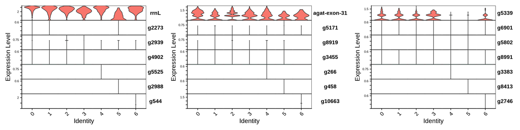

We noticed only one marker gene (g5339 in cluster 0) on the list with the high adjusted *P*-value (p_val_adj), so we filtered genes with p_val_adj >= 0.05

```r
so_pc27.markers %>% filter(p_val_adj < 0.05) %>% arrange(desc(avg_log2FC)) %>% group_by(cluster) %>% dplyr::slice(1:3) %>% as.data.frame()
```

```
##           p_val avg_log2FC pct.1 pct.2    p_val_adj cluster         gene
## 1  1.628286e-50  0.4794511 0.987 0.942 1.097302e-46       0         rrnL
## 2  1.822494e-13  0.4254225 0.694 0.637 1.228179e-09       0 agat-exon-31
## 3  1.918097e-08  0.3006779 0.766 0.743 1.292606e-04       0        g1809
## 4  1.927113e-06  3.0435564 0.021 0.002 1.298682e-02       1        g2273
## 5  5.189913e-14  2.3967886 0.074 0.013 3.497483e-10       1        g5171
## 6  5.249113e-06  2.2134814 0.032 0.007 3.537377e-02       1        g6901
## 7  1.567681e-46  2.6286600 0.240 0.040 1.056460e-42       2        g2939
## 8  6.290512e-19  2.3435993 0.119 0.025 4.239176e-15       2        g8919
## 9  1.071948e-08  2.2555593 0.052 0.011 7.223854e-05       2        g5802
## 10 6.283671e-07  2.2214795 0.043 0.009 4.234566e-03       3        g4902
## 11 6.180604e-06  2.1663379 0.037 0.008 4.165109e-02       3        g3455
## 12 1.006759e-10  1.9529906 0.089 0.023 6.784550e-07       3        g8991
## 13 2.806480e-13  6.4132086 0.023 0.000 1.891287e-09       4        g5525
## 14 2.806411e-13  5.9981711 0.023 0.000 1.891240e-09       4         g266
## 15 1.561558e-08  5.7351367 0.014 0.000 1.052334e-04       4        g3383
## 16 4.204149e-18  6.8180813 0.030 0.000 2.833176e-14       5        g2988
## 17 4.204149e-18  6.8180813 0.030 0.000 2.833176e-14       5         g458
## 18 4.204149e-18  6.8180813 0.030 0.000 2.833176e-14       5        g8413
## 19 5.576306e-49 10.0779520 0.085 0.000 3.757873e-45       6         g544
## 20 8.445546e-61  9.2154555 0.106 0.000 5.691453e-57       6       g10663
## 21 1.277865e-72  8.5633789 0.128 0.000 8.611534e-69       6        g2746
```

We can visualize the marker gene expression with filtered data.

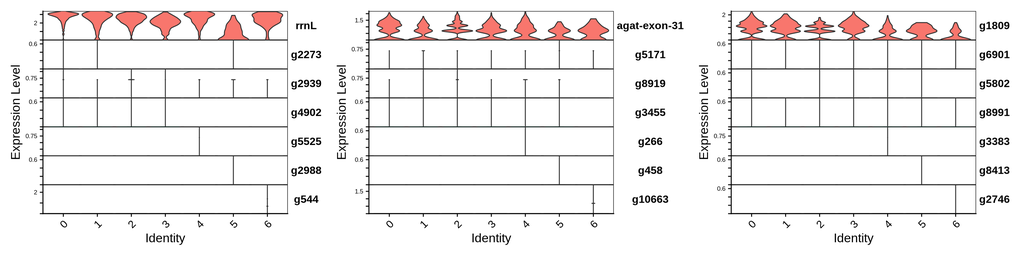

The below table shows top10 marker genes in each cluster with inferred gene names derived from annotated reference genomes *Bombyx mori*, *Danaus plexippus*, and *Plutella xylostella*.

```r
selected_markers <- so_pc27.markers %>% filter(p_val_adj < 0.05) %>% arrange(desc(avg_log2FC)) %>% group_by(cluster) %>% dplyr::slice(1:10)
gene_name <- read.delim("/media/nguyen/Data1/mao/braker3/phymatopus_californicus/genome_mao/annotation/gene_name/anno_combo_mito", header = F)
selected_markers %>% inner_join(gene_name, by=join_by(gene == V1)) %>% select(!c(V2,V3,V5,V6,V7,V8)) %>% rename(V4="Bombyx_mori") %>% as.data.frame()
```

```
##            p_val avg_log2FC pct.1 pct.2     p_val_adj cluster         gene
## 1   1.628286e-50  0.4794511 0.987 0.942  1.097302e-46       0         rrnL
## 2   1.822494e-13  0.4254225 0.694 0.637  1.228179e-09       0 agat-exon-31
## 3   1.918097e-08  0.3006779 0.766 0.743  1.292606e-04       0        g1809
## 4   1.885498e-06  0.2620691 0.845 0.861  1.270637e-02       0        g5827
## 5   1.927113e-06  3.0435564 0.021 0.002  1.298682e-02       1        g2273
## 6   5.189913e-14  2.3967886 0.074 0.013  3.497483e-10       1        g5171
## 7   5.249113e-06  2.2134814 0.032 0.007  3.537377e-02       1        g6901
## 8   1.832373e-06  2.0841984 0.039 0.009  1.234836e-02       1        g4945
## 9   6.883829e-07  2.0435564 0.044 0.011  4.639012e-03       1        g3535
## 10  6.671578e-06  1.9529538 0.039 0.010  4.495976e-02       1        g5865
## 11  1.072778e-06  1.9440207 0.046 0.012  7.229450e-03       1         g178
## 12  3.465617e-25  1.8321490 0.225 0.067  2.335479e-21       1        g2270
## 13  1.230733e-23  1.7709943 0.223 0.069  8.293913e-20       1        g7146
## 14  1.560446e-06  1.7622703 0.053 0.016  1.051585e-02       1        g3041
```

[output cut: 115 more lines]

# Note

The edited gtf file was tested together with STARsolo, and the yielded output is identical to that using the flawed gtf file.